# Regression Models Course Project

Milan Gerza

Thursday, September 18, 2014

## Synopsis

Many readers of our automobile industry magazine, the *“Motor Trends”*, are more and more interested in efficiency of fuel consumption. This study explores the relationship between type of transmission (automatic or manual), and MPG (miles per gallon) of a car.

Two main questions will be answered here:

1. *“Is an automatic or manual transmission better for MPG?”*
2. *“Quantify the MPG difference between automatic and manual transmissions”*

### Data preparation

The dataset is available by name **mtcars**. The format of the data is a data frame with 32 observations on 11 variables. The variables of intersets are *mpg* for miles per US gallon and *am* for transmission (0 = automatic, 1 = manual).

```
##                    mpg cyl disp  hp drat    wt  qsec vs am gear carb
## Mazda RX4         21.0   6  160 110 3.90 2.620 16.46  0  1    4    4
## Mazda RX4 Wag     21.0   6  160 110 3.90 2.875 17.02  0  1    4    4
## Datsun 710        22.8   4  108  93 3.85 2.320 18.61  1  1    4    1
## Hornet 4 Drive    21.4   6  258 110 3.08 3.215 19.44  1  0    3    1
## Hornet Sportabout 18.7   8  360 175 3.15 3.440 17.02  0  0    3    2
## Valiant           18.1   6  225 105 2.76 3.460 20.22  1  0    3    1
```

### Data exploration and interpretation

The quick data analysis shows (see Fig. 1 in Appendix) that there is a clear difference between the automobiles having automatic vs manual transmission. The mean and standard deviation of MPG vs transmission type summarizes following table:

```
##         Manual Automatic
## mpgMean 24.392    17.147
## mpgSd    6.167     3.834
```

### Hypotesis testing

Let us efine $H_0$ as “The difference in means of MPG in automatic vs manual transmission type is equal to 0.”. Alternative hypothesis $H_a$ statest that “True difference in means is greater than 0”. The dataset is small and we cannot argue about strict normality of the data, therefore we test using two sample t-test under 0.95 confidence level (ie. ${\alpha}$=0.05). Since the p-value is less than ${\alpha}$ we reject $H_0$ in favor of $H_a$. Details of the t-test:

```
##
##  Welch Two Sample t-test
##
## data:  x1 and x2
## t = 3.767, df = 18.33, p-value = 0.0006868
## alternative hypothesis: true difference in means is greater than 0
## 95 percent confidence interval:
##  3.913   Inf
## sample estimates:
## mean of x mean of y
##     24.39     17.15
```

### Fitting models, diagnostics and interpretation

Both linear and anova models were fitted into the data. The results do not show any significant difference in the model we select, so a linear model was selected. The intercept and predictor values are:

```
## (Intercept)          am
##      17.147       7.245
```

Summary of the linear model:

```
##
## Call:
## lm(formula = mpg ~ am, data = mtcars)
##
## Residuals:
##    Min     1Q Median     3Q    Max
## -9.392 -3.092 -0.297  3.244  9.508
##
## Coefficients:
##             Estimate Std. Error t value Pr(>|t|)
## (Intercept)    17.15       1.12   15.25  1.1e-15 ***
## am              7.24       1.76    4.11  0.00029 ***
## ---
## Signif. codes:  0 '***' 0.001 '**' 0.01 '*' 0.05 '.' 0.1 ' ' 1
##
## Residual standard error: 4.9 on 30 degrees of freedom
## Multiple R-squared:  0.36,   Adjusted R-squared:  0.338
## F-statistic: 16.9 on 1 and 30 DF,  p-value: 0.000285
```

The coefficients can be interpreted in a way that change from automatic to manual transmission increases MPG of a car by 7.2449 , with signif. level 0.999.

For the plot of residual variances see Fig. 2 of Appendix.

## Summary

We than therefore answer questions of interest following way: The manual transmission type is better for MPG than automatic one. The difference between automatic and manual transmission is 7.2449 MPG in favor of manual transmission type..

# Appendix

```
## [1] "Fig. 1, Quick view on data of interest"
```

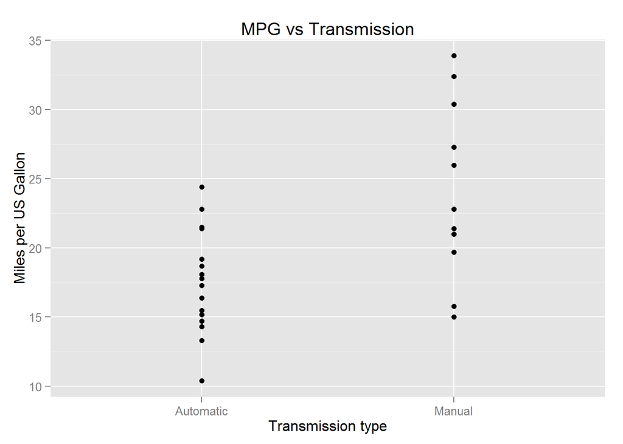

```
## [1] "Fig. 2, Residual plot"
```

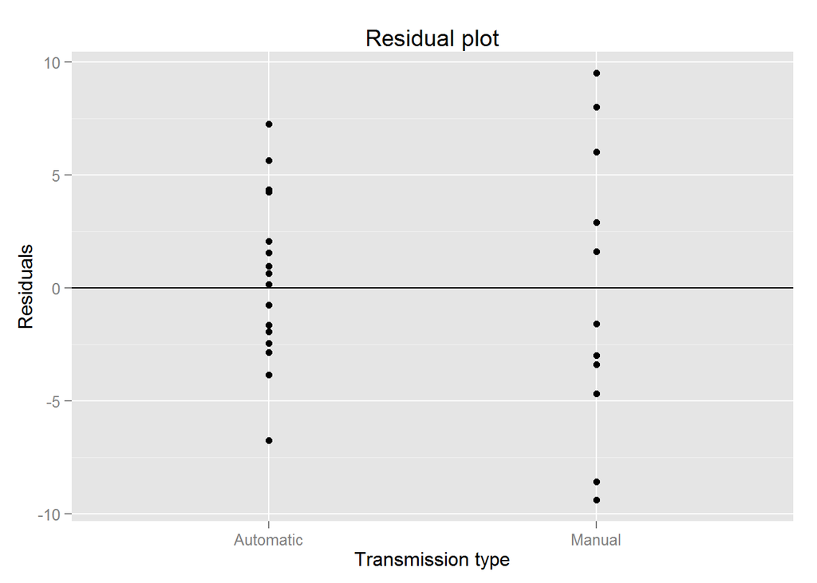